# IE 360 - HW2

```
Call:
lm(formula = UGS ~ Trend + Quarter + UGS_lag1 + UGS_lag2, data = dt)

Residuals:
   Min     1Q Median     3Q    Max
-80724 -22526   9719  18683  55549

Coefficients:
              Estimate Std. Error t value Pr(>|t|)
(Intercept)  3.262e+05  3.133e+05   1.041  0.31087
Trend       -4.940e+03  3.600e+03  -1.372  0.18598
Quarter2     2.234e+05  4.599e+04   4.856  0.00011 ***
Quarter3     4.138e+05  6.867e+04   6.026  8.5e-06 ***
Quarter4     1.689e+05  7.068e+04   2.389  0.02740 *
UGS_lag1     5.506e-02  2.358e-01   0.234  0.81784
UGS_lag2     4.644e-01  2.168e-01   2.143  0.04532 *
---
Signif. codes:  0 '***' 0.001 '**' 0.01 '*' 0.05 '.' 0.1 ' ' 1

Residual standard error: 40920 on 19 degrees of freedom
  (6 observations deleted due to missingness)
Multiple R-squared:  0.9417,	Adjusted R-squared:  0.9233
F-statistic: 51.17 on 6 and 19 DF,  p-value: 1.014e-10
```

```
	Breusch-Godfrey test for serial correlation of order up to 10

data:  Residuals
LM test = 15.654, df = 10, p-value = 0.11
```

9.78635975675738e-13

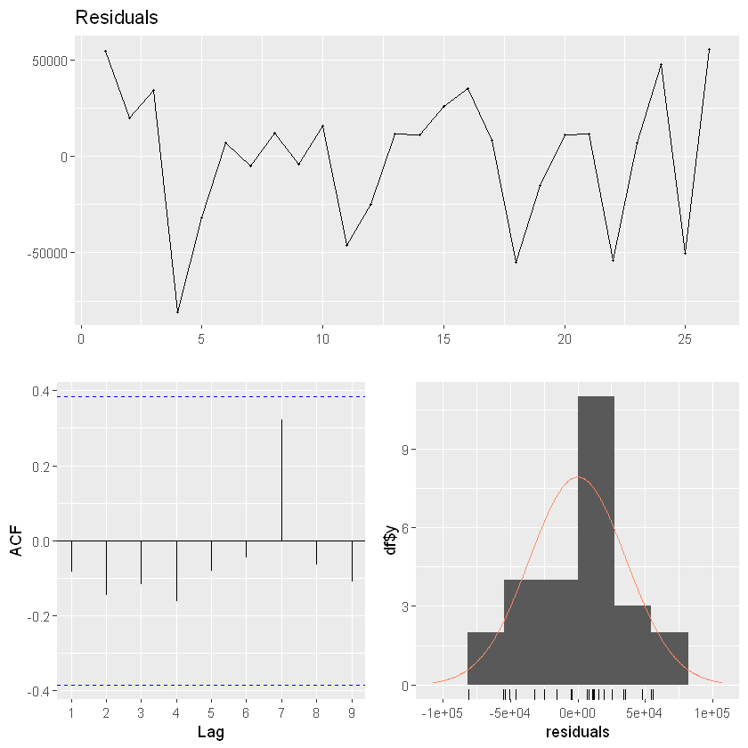

```r
model4 <- lm(UGS~Trend+Quarter+UGS_lag1+UGS_lag2, dt)
summary(model4)
checkresiduals(model4)
mean(model4$residuals)
```

```
Call:
lm(formula = UGS ~ Trend + Quarter + UGS_lag2, data = dt)

Residuals:
   Min     1Q Median     3Q    Max
-78490 -25706  10316  20897  55505

Coefficients:
              Estimate Std. Error t value Pr(>|t|)
(Intercept)  3.617e+05  2.673e+05   1.354   0.1910
Trend       -5.401e+03  2.940e+03  -1.837   0.0811 .
Quarter2     2.223e+05  4.466e+04   4.977 7.25e-05 ***
Quarter3     4.218e+05  5.814e+04   7.255 5.10e-07 ***
Quarter4     1.828e+05  3.739e+04   4.888 8.90e-05 ***
UGS_lag2     4.848e-01  1.937e-01   2.504   0.0211 *
---
Signif. codes:  0 '***' 0.001 '**' 0.01 '*' 0.05 '.' 0.1 ' ' 1

Residual standard error: 39940 on 20 degrees of freedom
  (6 observations deleted due to missingness)
Multiple R-squared:  0.9416,	Adjusted R-squared:  0.9269
F-statistic: 64.44 on 5 and 20 DF,  p-value: 1.215e-11
```

```
	Breusch-Godfrey test for serial correlation of order up to 9

data:  Residuals
LM test = 15.455, df = 9, p-value = 0.07917
```

1.29482749308898e-12

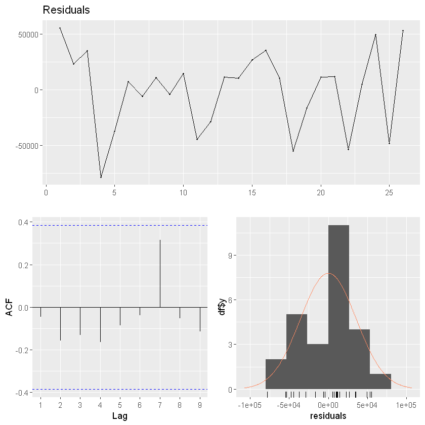

```r
model5 <- lm(UGS~Trend+Quarter+UGS_lag2, dt)
summary(model5)
checkresiduals(model5)
mean(model5$residuals)
```

The best adjusted R-squared value is obtained with just UGS_lag2. But high autocorrelation at lag 7 made me think of including UGS_lag3.

```
Call:
lm(formula = UGS ~ Trend + Quarter + UGS_lag2 + UGS_lag3, data = dt)

Residuals:
   Min     1Q Median     3Q    Max
-68074 -20759   5228  20379  52547

Coefficients:
              Estimate Std. Error t value Pr(>|t|)
(Intercept)  5.292e+05  3.084e+05   1.716 0.103299
Trend       -6.380e+03  3.480e+03  -1.834 0.083312 .
Quarter2     1.767e+05  7.465e+04   2.367 0.029372 *
Quarter3     3.606e+05  6.857e+04   5.258 5.32e-05 ***
Quarter4     1.603e+05  3.948e+04   4.061 0.000733 ***
UGS_lag2     3.045e-01  2.328e-01   1.308 0.207416
UGS_lag3     5.618e-02  2.229e-01   0.252 0.803897
---
Signif. codes:  0 '***' 0.001 '**' 0.01 '*' 0.05 '.' 0.1 ' ' 1

Residual standard error: 38670 on 18 degrees of freedom
  (7 observations deleted due to missingness)
Multiple R-squared:  0.9296,	Adjusted R-squared:  0.9061
F-statistic: 39.61 on 6 and 18 DF,  p-value: 2.051e-09
```

```
	Breusch-Godfrey test for serial correlation of order up to 10

data:  Residuals
LM test = 17.922, df = 10, p-value = 0.0563
```

4.73221462016227e-13

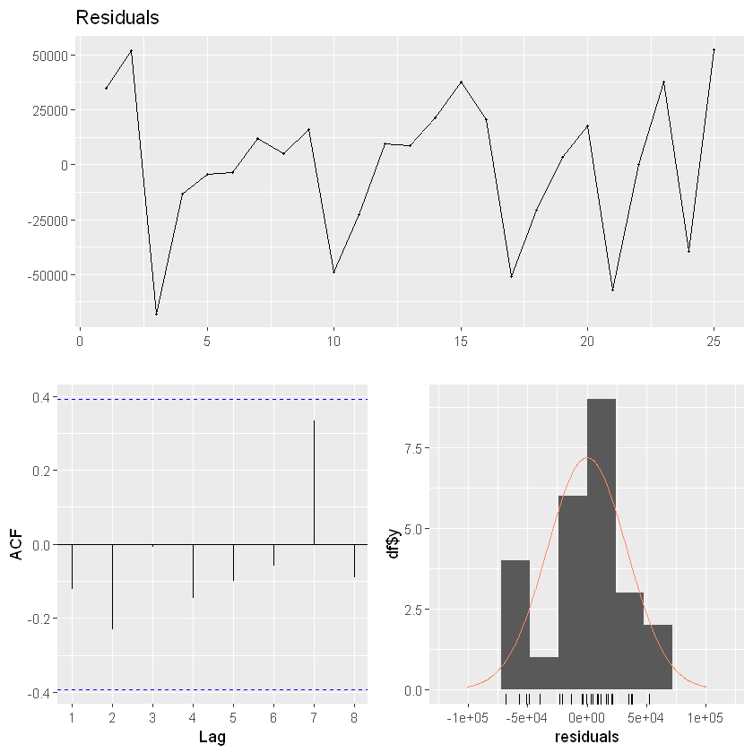

```r
model6 <- lm(UGS~Trend+Quarter+UGS_lag2+UGS_lag3, dt)
summary(model6)
checkresiduals(model6)
mean(model6$residuals)
```

That didn't work well. We can add the other independent variables.

```
Call:
lm(formula = UGS ~ Trend + Quarter + UGS_lag2 + PU, data = dt)

Residuals:
   Min     1Q Median     3Q    Max
-61183 -18461   1605  19631  52416

Coefficients:
              Estimate Std. Error t value Pr(>|t|)
(Intercept)  6.559e+05  2.509e+05   2.614  0.01705 *
Trend       -3.019e+03  2.652e+03  -1.138  0.26908
Quarter2     2.248e+05  3.828e+04   5.874 1.17e-05 ***
Quarter3     4.240e+05  4.982e+04   8.511 6.60e-08 ***
Quarter4     1.760e+05  3.213e+04   5.478 2.76e-05 ***
UGS_lag2     4.445e-01  1.665e-01   2.669  0.01517 *
PU          -5.624e+02  1.959e+02  -2.871  0.00979 **
---
Signif. codes:  0 '***' 0.001 '**' 0.01 '*' 0.05 '.' 0.1 ' ' 1

Residual standard error: 34220 on 19 degrees of freedom
  (6 observations deleted due to missingness)
Multiple R-squared:  0.9592,	Adjusted R-squared:  0.9464
F-statistic: 74.52 on 6 and 19 DF,  p-value: 3.513e-12
```

```
	Breusch-Godfrey test for serial correlation of order up to 10

data:  Residuals
LM test = 7.5069, df = 10, p-value = 0.6769
```

1.50430095730441e-12

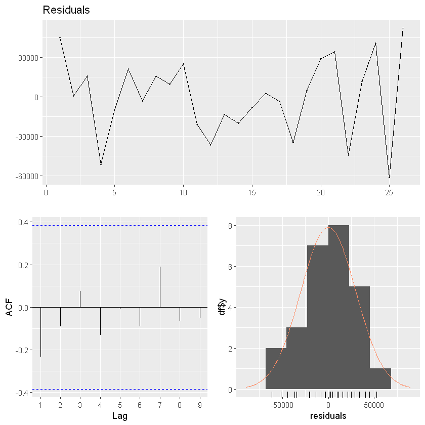

```r
model7 <- lm(UGS~Trend+Quarter+UGS_lag2+PU, dt)
summary(model7)
checkresiduals(model7)
mean(model7$residuals)
```

I tried to include each variable as well as 1 quarter lagged PU, number of new unleaded gasoline using vehicles, number of lost unleaded gasoline using vehicles; and PU gave the most improvement in the adjusted R-squared and the residuals. However now the trend variable doesn't seem to be significant based on its p value of t-test.

```
Call:
lm(formula = UGS ~ Quarter + UGS_lag2 + PU, data = dt)

Residuals:
   Min     1Q Median     3Q    Max
-70633 -10616   -390  29231  39933

Coefficients:
              Estimate Std. Error t value Pr(>|t|)
(Intercept)  4.567e+05  1.811e+05   2.522  0.02026 *
Quarter2     2.579e+05  2.510e+04  10.274 2.01e-09 ***
Quarter3     4.708e+05  2.836e+04  16.601 3.66e-13 ***
Quarter4     2.008e+05  2.375e+04   8.455 4.91e-08 ***
UGS_lag2     6.071e-01  8.616e-02   7.047 7.81e-07 ***
PU          -6.322e+02  1.875e+02  -3.372  0.00303 **
---
Signif. codes:  0 '***' 0.001 '**' 0.01 '*' 0.05 '.' 0.1 ' ' 1

Residual standard error: 34480 on 20 degrees of freedom
  (6 observations deleted due to missingness)
Multiple R-squared:  0.9565,	Adjusted R-squared:  0.9456
F-statistic: 87.86 on 5 and 20 DF,  p-value: 6.542e-13
```

```
	Breusch-Godfrey test for serial correlation of order up to 9

data:  Residuals
LM test = 8.6494, df = 9, p-value = 0.4702
```

8.39943499368718e-13

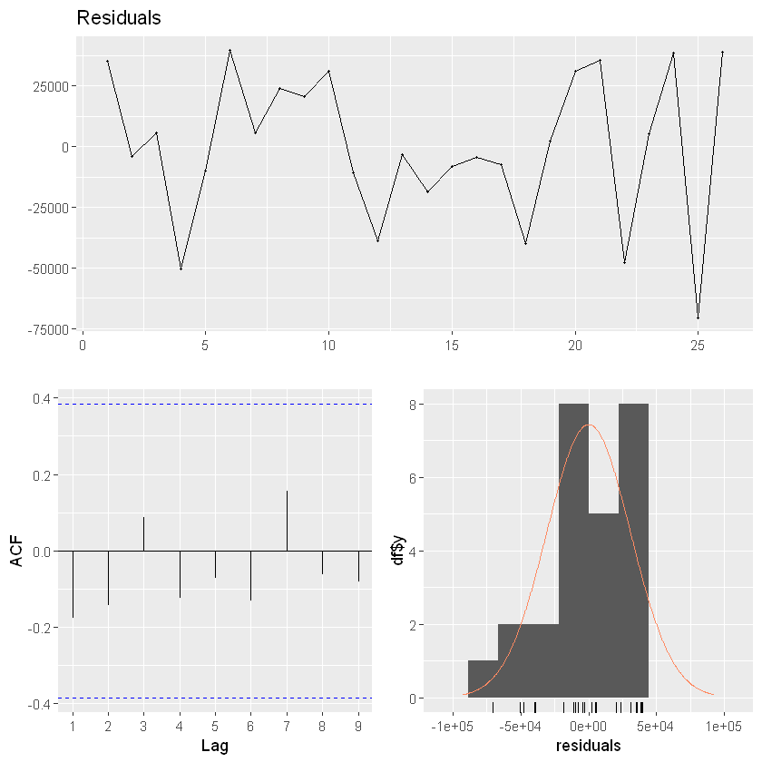

```r
model8 <- lm(UGS~Quarter+UGS_lag2+PU, dt)
summary(model8)
checkresiduals(model8)
mean(model8$residuals)
```

The residuals obtained with trend were more looking like normally distributed. So, I will go with the model including the trend variable. Furthermore, I tried adding more and more variables to improve model performance, and it did. But, actually I don't want to do so. Because, having number of diesel gasoline using vehicles with positive coefficient, number of unleaded gasoline using vehicles with negative coefficient, variables derived just to increase performance without a causality for such a small dataset, leads to poor interpretability and spuriousity as I mentioned before. To illustrate it better, I will build a model by employing forward and backward selection based on AIC and obtain the best performing model.

```r
exaggerated_model <- lm(UGS ~.-Year_Quarter-Year-Lost_NUGV, data = dt)
step_model <- stepAIC(exaggerated_model, direction = "both",
                      trace = FALSE)
summary(step_model)
```

```
Call:
lm(formula = UGS ~ RNUV + NLPG + PU + PG + NUGV + NDGV + GNPA +
    GNPC + GNP + Quarter + Trend + UGS_lag1 + UGS_lag2 + UGS_lag4 +
    UGS_lag5 + New_NUGV + Vehicle_Ratio, data = dt)

Residuals:
       6        7        8        9       10       11       12       13
 -2452.0   -393.6   2679.4   1923.2   1765.4  -1252.6  -2790.2   -127.8
      14       15       16       17       18       19       20       21
  3194.1  -2802.9   -223.5  -2768.4   -493.2   3398.0   4642.4   4171.3
      22       23       24       25       26       27       28
-12318.0   4324.2  -3607.0  -3198.3  10303.7  -3273.1   -701.1

Coefficients:
                Estimate Std. Error t value Pr(>|t|)
(Intercept)   -1.730e+08  3.637e+07  -4.757   0.0176 *
RNUV           2.812e+07  5.342e+07   0.526   0.6351
NLPG           2.597e+00  6.447e-01   4.029   0.0275 *
PU            -2.951e+03  1.050e+03  -2.812   0.0672 .
PG             7.992e+03  2.436e+03   3.280   0.0464 *
NUGV          -3.578e+01  7.183e+00  -4.981   0.0156 *
NDGV           6.156e+05  1.242e+05   4.956   0.0158 *
GNPA          -7.217e-02  4.386e-02  -1.645   0.1984
GNPC          -8.986e-01  2.081e-01  -4.319   0.0229 *
GNP            1.883e-01  3.553e-02   5.301   0.0131 *
Quarter2       4.736e+05  1.243e+05   3.811   0.0318 *
Quarter3       1.174e+06  3.139e+05   3.740   0.0333 *
Quarter4       7.055e+05  1.602e+05   4.403   0.0217 *
Trend         -1.713e+05  3.777e+04  -4.536   0.0201 *
UGS_lag1      -8.881e-01  1.545e-01  -5.748   0.0105 *
UGS_lag2      -4.539e-01  1.183e-01  -3.836   0.0312 *
UGS_lag4      -1.399e+00  2.721e-01  -5.144   0.0142 *
UGS_lag5      -1.029e+00  2.982e-01  -3.452   0.0409 *
New_NUGV      -6.384e+00  9.690e+00  -0.659   0.5571
Vehicle_Ratio  1.018e+04  2.096e+03   4.856   0.0167 *
---
Signif. codes:  0 '***' 0.001 '**' 0.01 '*' 0.05 '.' 0.1 ' ' 1

Residual standard error: 11790 on 3 degrees of freedom
  (9 observations deleted due to missingness)
Multiple R-squared:  0.9988,	Adjusted R-squared:  0.9911
F-statistic: 130.5 on 19 and 3 DF,  p-value: 0.0009555
```

Adjusted R-squared value obtained is jumped to 0.9911 but I think this model has no value in terms of interpretability. So I will assign the final model to model7 which was including trend, quarter of the year, unleaded gasoline price index, and 2 quarters lagged unleaded gasoline sales.

### 5.4. Final Model and Analysis

```r
final_model <- model7
```

```
Call:
lm(formula = UGS ~ Trend + Quarter + UGS_lag2 + PU, data = dt)

Residuals:
   Min     1Q Median     3Q    Max
-61183 -18461   1605  19631  52416

Coefficients:
              Estimate Std. Error t value Pr(>|t|)
(Intercept)  6.559e+05  2.509e+05   2.614  0.01705 *
Trend       -3.019e+03  2.652e+03  -1.138  0.26908
Quarter2     2.248e+05  3.828e+04   5.874 1.17e-05 ***
Quarter3     4.240e+05  4.982e+04   8.511 6.60e-08 ***
Quarter4     1.760e+05  3.213e+04   5.478 2.76e-05 ***
UGS_lag2     4.445e-01  1.665e-01   2.669  0.01517 *
PU          -5.624e+02  1.959e+02  -2.871  0.00979 **
---
Signif. codes:  0 '***' 0.001 '**' 0.01 '*' 0.05 '.' 0.1 ' ' 1

Residual standard error: 34220 on 19 degrees of freedom
  (6 observations deleted due to missingness)
Multiple R-squared:  0.9592,	Adjusted R-squared:  0.9464
F-statistic: 74.52 on 6 and 19 DF,  p-value: 3.513e-12
```

```
	Breusch-Godfrey test for serial correlation of order up to 10

data:  Residuals
LM test = 7.5069, df = 10, p-value = 0.6769
```

1.50430095730441e-12

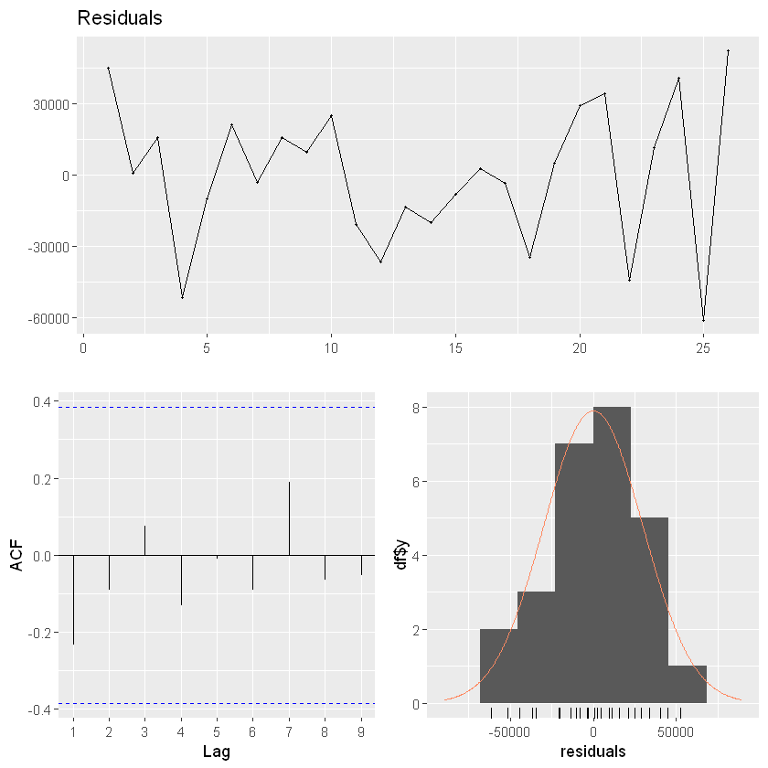

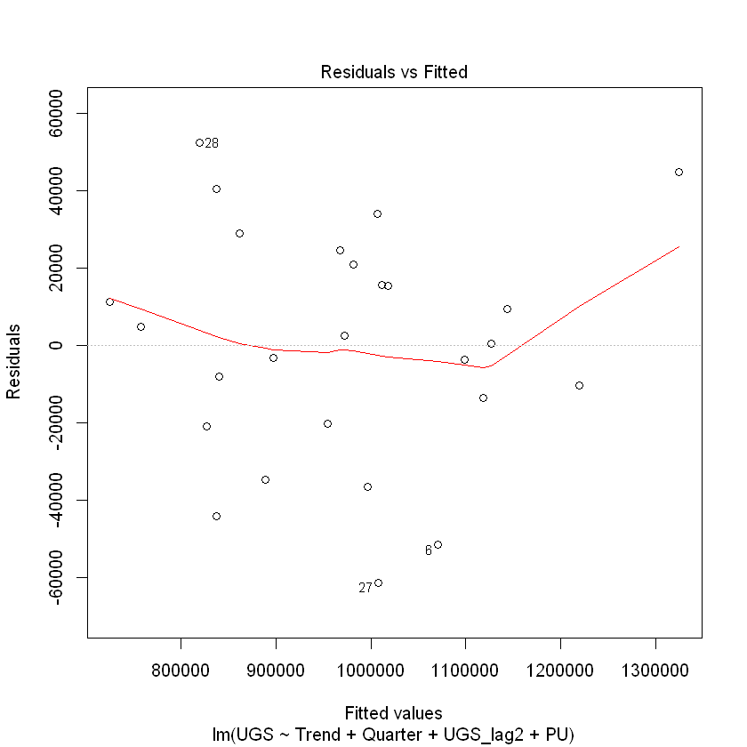

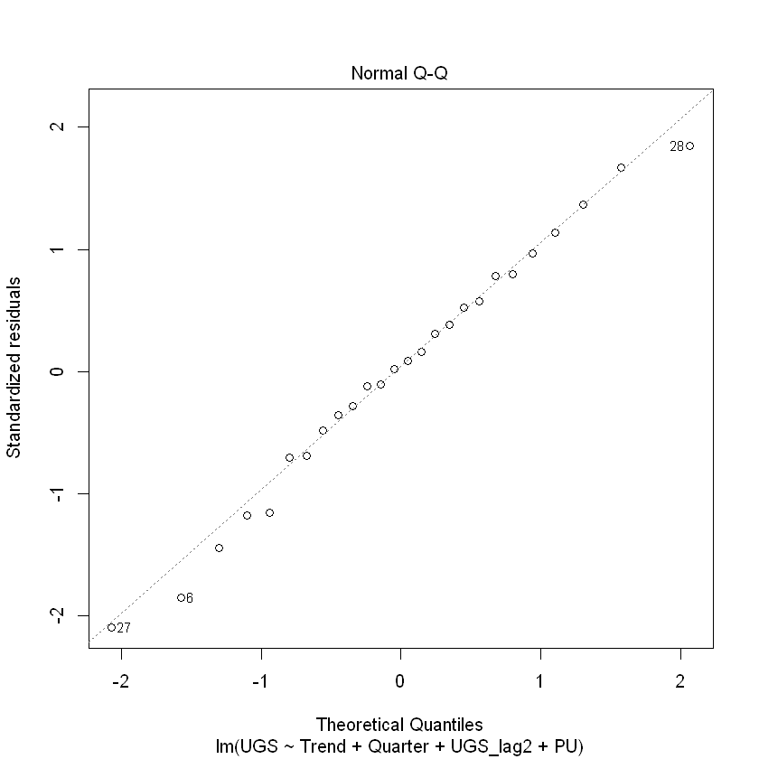

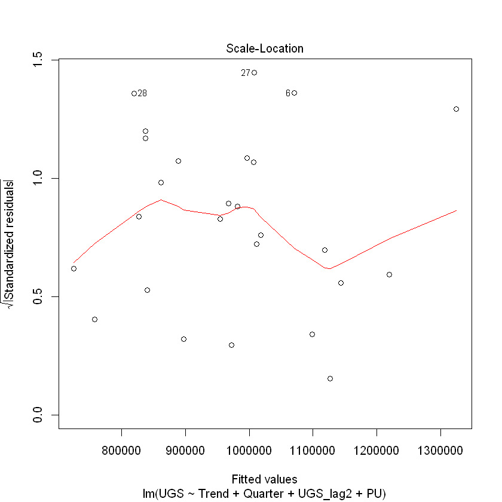

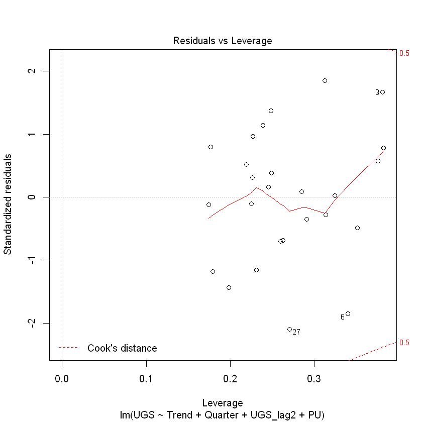

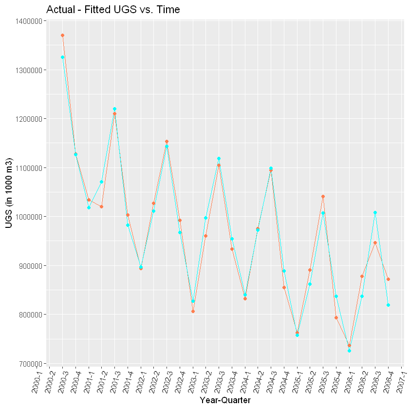

```r
summary(final_model)
checkresiduals(final_model)
mean(final_model$residuals)
plot(final_model)
ggplot(dt[Year < 2007 & Trend > 2], aes(x=Year_Quarter)) + geom_line(aes(y=UGS), color="coral") + geom_line(aes(y=final_model$fitted.values), color="cyan") +
    geom_point(aes(y=UGS), color="coral") + geom_point(aes(y=final_model$fitted.values), color="cyan") +
    labs(title = "Actual - Fitted UGS vs. Time", x = "Year-Quarter", y = "UGS (in 1000 m3)") +
    scale_x_yearqtr(breaks = dt[, Year_Quarter], minor_breaks = dt[, Year_Quarter]) +
    theme(axis.text.x=element_text(angle=75,  hjust=1.4, vjust = 1.4)) +
    scale_y_continuous(breaks = 100000*seq(from = 7, to = 14, by = 1), minor_breaks = 100000*seq(from = 7,to = 14,by = .5))
```

Firstly, p-value associated with the F-statistic of the overall model is very small indicating that the model is meaningful. When we look at the p-values of each variable's t-statistic, we can say that quarterly seasonality is the most important variable. Also the other variables except trend came out to be significant. The case with the trend is mentioned before. Intercept covers the effect of Quarter1 and the rest coefficients are relational to Quarter1. Price and Trend have negative coefficients as expected from the visualizations. Adjusted R-squared of the model is 0.9464 which is an acceptable, nice value. Residuals are ranging from -61 thousand to 52 thousand. The mean of the residuals is very close to 0 which is the assumption of linear regression. However, at the last year, the residuals seem to be getting larger and negatively autocorrelated. But it is a very small dataset and it is a very short time window to be worried. The histogram and the normal q-q plot of the residuals are suggesting that the residuals are distributed normally which is again an assumption of linear regression. Also, all of the autocorrelation function values at each lag is inside the boundaries which suggests the residuals are independent. The constant variance of the residuals assumption is holding if we ignore the last part.

### 5.5. Forecasting

```r
forecast <- c()
for(i in 1:4){
    forecast[i] <- predict(final_model, newdata = dt[Year == 2007 & Quarter == as.factor(i)])
    if(i <= 2){
        dt[Year == 2007 & Quarter == i+2]$UGS_lag2 <- forecast[i]
    }
}
dt[, Forecast := c(rep(NA, 2), final_model$fitted.values, forecast)]
dt[Year == 2007, c("Year_Quarter", "Forecast")]
```

| Year_Quarter | Forecast |
| --- | --- |
| 2007 Q1 | 671312.0 |
| 2007 Q2 | 859897.9 |
| 2007 Q3 | 966879.4 |
| 2007 Q4 | 799632.5 |

## 6. Conclusion

In this report, the quarterly unleaded gasoline sales information is forecasted by using 2 quarters behind information, price index of the unleaded gasoline, trend and quarter of the year seasonal components. Most of the possible ways to include more variables in the dataset were tried but due to interpretability and spuriousity issues, most of them were not added to the model. At the end, the forecasted values for 2007 are provided.